# Teoría en Diseño Experimental

¿Pensaste que ibas a escapar de la teoría, verdad?

Rosario Aguilar

rosario.aguilar@newcastle.ac.uk

Newcastle University

Danilo Freire

danilo.freire@emory.edu

Emory University

24-08-2024

# Causalidad y experimentos 👩‍🔬 🧪

## ¿Por qué la teoría?

- Como investigadores, estamos interesados en preguntas de investigación sobre cómo funciona el mundo.
- Hay varios tipos de preguntas que podemos querer responder.
  - **Preguntas descriptivas**: Descripciones de un fenómeno dado: por ejemplo, “*¿cómo los burócratas distribuyen su tiempo entre diferentes tareas?*”
  - **Preguntas causales**: Preguntas sobre *cómo* X afecta a Y: por ejemplo, “*¿Proporcionar formación profesional a los migrantes mejora su integración económica en el país receptor?*”

[figure not shown]

## Teoría

- ¿Cuál es el fenómeno que queremos explicar?
  - **Nuestro resultado** (lo vamos a llamar **Y**)
- ¿La causa que teorizamos lleva a observar cambios en Y?
  - **Nuestro tratamiento** (en el contexto de experimentos) (lo vamos a llamar $\mathcal{T}$)
- ¿Cuál es la teoría del cambio?
- En última instancia, estamos interesados en cómo dos conceptos teóricos están relacionados, medidos por variables observadas $\mathcal{T}$ (nuestro tratamiento) y Y (nuestros resultados)

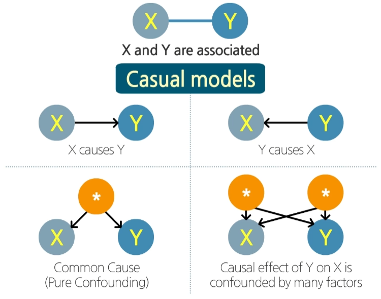

## ¿Por qué es importante la teoría?

- Nuestra teoría nos permite:
- Derivar implicaciones observables (hipótesis) que probamos en el mundo real.
- Separar dos experimentos completamente no relacionados con propiedades empíricas idénticas para Y y $\mathcal{T}$
  - Por ejemplo, podríamos tener dos experimentos de tamaño idéntico con la misma asignación de tratamiento, los mismos resultados observados, pero con teorías subyacentes significativamente diferentes.

## De la teoría al diseño de investigación

- Luego necesitamos conectar lo que nos interesa con lo que observamos en el mundo real $\rightarrow$ operacionalización de conceptos teóricos.
- ¿Cómo vamos a *medir* nuestros resultados? ¿Cómo vamos a *manipular* la causa de interés?
- Este vínculo estrecho entre teoría y diseño de investigación nos ayuda a interpretar los resultados de nuestro experimento.

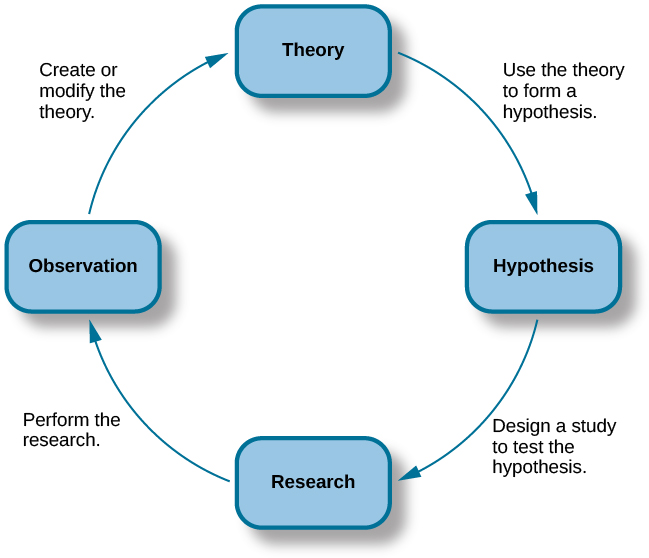

## Medición

- La medición es el vínculo entre la teoría de un investigador y un diseño de investigación (experimental).
- La medición sigue entonces de nuestra teoría de cómo creemos que funciona el mundo y cómo nuestro tratamiento manipula ese mundo.
- El caso ideal es la medición directa del fenómeno de interés sin error. Pero esto generalmente no es posible.
- A menudo solo podemos medir indicadores conectados al fenómeno subyacente de interés.

[figure not shown]

## Consideremos el ejemplo de nuestro experimento

- ¿Cuál es el resultado de interés (Y)?
- ¿Cuál es la causa de interés ($\mathcal{T}$)?
- ¿Cuál puede ser una teoría que conduzca a este diseño experimental?
- ¿Cuál puede ser la hipótesis principal?

## Medición de tratamientos

- ¿Podemos manipular directamente $\mathcal{T}$? (concepto de tratamiento subyacente de interés)
  - Consideraciones éticas, logísticas y de otro tipo pueden limitar nuestra capacidad de manipular todos los indicadores de $\mathcal{T}$.
  - En el mejor de los casos, podemos cambiar algunos de sus indicadores.
  - Diseñamos un tratamiento, **T**, para hacerlo.
- ¿Cómo se relaciona **T** con $\mathcal{T}$?
  - Pero **T** puede estar manipulando otras cosas (tratamientos combinados).
- ¿Todos recibieron **T**?
  - Medir el cumplimiento.

## Pensando en el tratamiento…

- Ahora piensen en ustedes mismos como los investigadores.
- En parejas o grupos de tres:
  - Generen hipótesis sobre la dirección del efecto promedio esperado
  - Generen hipótesis sobre posibles efectos heterogéneos
  - Generen el tamaño del efecto esperado
  - Discutan las teorías detrás de la hipótesis y el tamaño del efecto esperado, con énfasis en la importancia de la teoría
  - ¿Otras formas de medir el resultado o modo de administrar el tratamiento?

## Midiendo los resultados

- Como científicos sociales, no podemos observar directamente el valor verdadero del concepto de resultado para la mayoría de los resultados que nos interesan.
- Ejemplos:
  - Respuestas correctas a problemas (indicadores) para la aptitud matemática subyacente (el fenómeno real).
  - Días sin comida (indicadores) para el hambre (el fenómeno real).
  - Informes de sobornos (indicadores) para la corrupción (el fenómeno real).
- Además, el concepto de resultado subyacente puede estar incluso en debate (por ejemplo, la democracia).
- Si nuestros indicadores no miden el concepto subyacente que nos interesa, entonces es posible que no podamos aprender mucho, incluso si tenemos un experimento por lo demás muy sólido.

## Volviendo a nuestro experimento…

- ¿Qué elementos están diseñados para medir nuestro resultado teórico de interés (**Y**)?
  - ¿Alguna preocupación sobre esta operacionalización?
  - ¿Otras formas posibles de medir Y?

## Cosas a considerar

- Los problemas con la medición pueden llevarte a sacar inferencias causales incorrectas de tu estudio (error sistemático, más sesgo).
- La medición con ruído reduce la potencia (error aleatorio, menos precisión) [discutiremos esto después].
- La recolección de datos a menudo ocupa una porción muy grande del tiempo y los recursos financieros disponibles en el presupuesto del proyecto.

[figure not shown]

## Para concluir

- Como investigadores, tenemos teorías sobre cómo funciona el mundo.
- Algunas de estas teorías implican afirmaciones causales, y podemos usar experimentos para probarlas empíricamente (es decir, con los datos que observamos del mundo real).
- La medición conecta la teoría y el diseño de la investigación.
- Observamos indicadores del mundo real de los conceptos teóricos más amplios que nos interesan.

[Teoría](https://danilofreire.github.io/ldm/theory.html)